# Modelo Share of Market

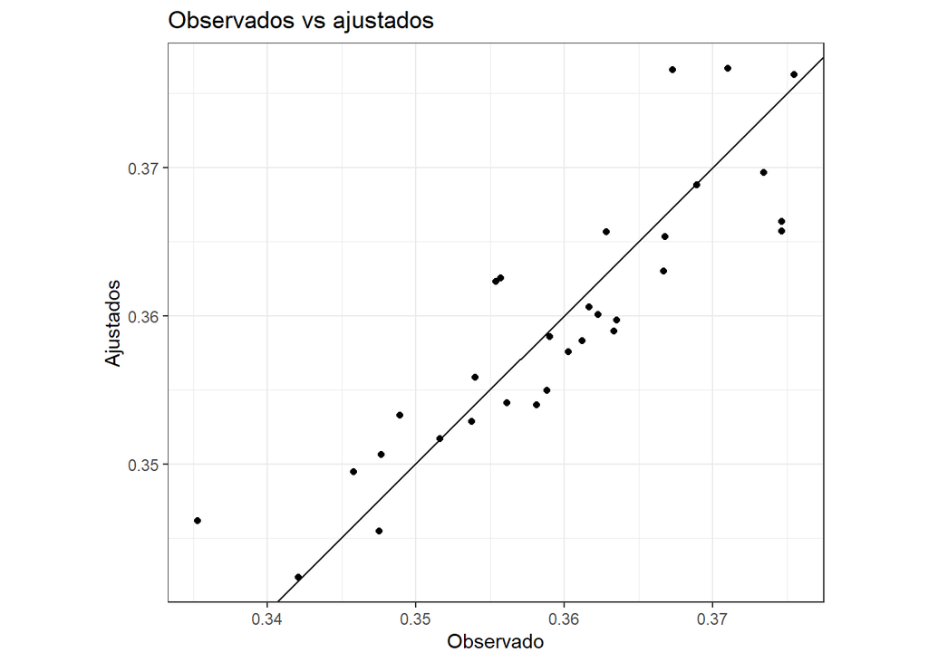

```r
# Gráfico de ajustados vs observados

train_preds %>%
  ggplot(aes(share, q_5)) +
  geom_point() +
  geom_abline(intercept = 0, slope = 1) +
  coord_equal() +
  labs(title = 'Observados vs ajustados', x = 'Observado', y = 'Ajustados') +
  theme(legend.position = 'bottom') +
  theme_bw()
```

```r
#Prediccióm

train_PTY2 <- train_PTY %>%
  rbind(test_PTY %>%
          mutate(share_A = NA))

jags_PTY2 <- list(
  share_A = train_PTY2$share_A,
  dist_num_A = train_PTY2$dist_num_A,
  ventas_unidades_A = train_PTY2$ventas_unidades_A,
  inversion_promos_tv_A = train_PTY2$inversion_promos_tv_A,
  ventas_unidades_B = train_PTY2$ventas_unidades_B,
  ppu_B = train_PTY2$ppu_B,
  inventarios_B = train_PTY2$inventarios_B,
  n = nrow(train_PTY),
  m = nrow(test_PTY)
)

#Parametros a guardar

jags_param_PTY2 <- c("be", "pred")

#JAGS
set.seed(1789152)
jags_model_PTY2 <- jags(jags_PTY2, jags.inits_PTY, jags_param_PTY2,
                   model.file = "libraries/modelo_fem_pronostico_PTY",
                   n.iter = 50000,
                   n.chains = 1,
                   n.thin = 1,
                   n.burnin = 5000)
jags_sims_PTY2 <- jags_model_PTY2$BUGSoutput$sims.matrix %>% as.data.frame()

train_preds_PTY <- jags_sims_PTY2 %>%
  dplyr::select(contains("pred")) %>%
  gather(parametro, sim) %>%
  mutate(mu_num = as.numeric(str_extract(parametro, '[0-9]+'))) %>%
  group_by(mu_num) %>%
  summarise(q_1 = quantile(sim, probs = 0.05),
            q_5 = median(sim),
            q_9 = quantile(sim, probs = 0.95),
            media = mean(sim)) %>%
  ungroup %>%
  cbind(share_A = train_PTY2$share_A) %>%
  dplyr::select(share_A, media, q_1:q_9)
```

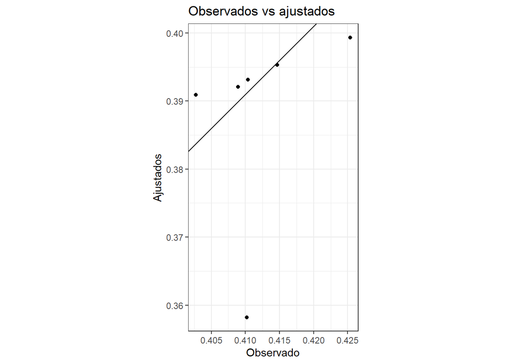

```r
ajuste_pronos_PTY <- train_preds_PTY %>%
  filter(is.na(share_A)) %>%
  dplyr::select(-share_A) %>%
  cbind(test_PTY %>% dplyr::select(share_A)) %>%
  dplyr::select(share_A, q_5)

cor_PTY <- cor(ajuste_pronos_PTY$share_A, ajuste_pronos_PTY$q_5)^2


ajuste_pronos_PTY %>%
  ggplot(aes(share_A, q_5)) +
  geom_point() +
  geom_abline(intercept = -0.019, slope = 1) +
  labs(title = 'Observados vs ajustados', x = 'Observado', y = 'Ajustados') +
  theme(legend.position = 'bottom') +
  coord_equal() +
  theme_bw()
```

### Honduras

```r
#Datos train para El Salvador
train_HD <- datos_ajuste %>% filter(pais == "HD")
test_HD <- datos_prueba %>% filter(pais == "HD")

#Stepwise para ver cuales variables son las buenas
full_HD <- lm(share_A~., data = train_HD[,3:15])
step.model_HD <- stepAIC(full_HD, direction = "both", trace = FALSE)
summary(step.model_HD)
```

```
##
## Call:
## lm(formula = share_A ~ ventas_unidades_A + dist_num_B + agot_num_B +
##     ventas_unidades_B, data = train_HD[, 3:15])
##
## Residuals:
##       Min        1Q    Median        3Q       Max
## -0.004375 -0.001196  0.000408  0.000988  0.004197
##
## Coefficients:
##                     Estimate Std. Error t value Pr(>|t|)
## (Intercept)        1.822e-01  1.873e-02   9.723 3.79e-10 ***
## ventas_unidades_A  7.495e-08  2.308e-09  32.477  < 2e-16 ***
## dist_num_B         6.296e-04  2.299e-04   2.739    0.011 *
## agot_num_B        -3.179e-04  2.122e-04  -1.498    0.146
## ventas_unidades_B -2.602e-08  9.828e-10 -26.476  < 2e-16 ***
## ---
## Signif. codes:  0 '***' 0.001 '**' 0.01 '*' 0.05 '.' 0.1 ' ' 1
##
## Residual standard error: 0.001791 on 26 degrees of freedom
## Multiple R-squared:  0.9797, Adjusted R-squared:  0.9766
## F-statistic: 313.4 on 4 and 26 DF,  p-value: < 2.2e-16
```

```r
#Almacenamiento de variables
jags_HD <- list(
  share_A = train_HD$share_A,
  ventas_unidades_A = train_HD$ventas_unidades_A,
  dist_num_B = train_HD$dist_num_B,
  agot_num_B = train_HD$agot_num_B,
  ventas_unidades_B = train_HD$ventas_unidades_B,
  n = nrow(train_HD)
)

#Declaración distribuciones iniciales (no informativas)
jags.inits_HD <- function(){
  list(be = rep(0,5),
       tau = 1)
}

# Seleccionamos los parámetros a monitorear
jags_param_HD <- c("be", "pred")

# Asociamos variables con coeficientes

coef_variables <- data.frame(
  parametro = c(paste0('be_', 1:5)),
  variable = c('Intercepto',
               'ventas_unidades_A',
               'dist_num_B',
               'agot_num_B',
               'Ventas_unidades_B')
)


# Codigo
set.seed(17891525)
jags_model_HD <- jags(jags_HD, jags.inits_HD, jags_param_HD,
                   model.file = "libraries/modelo_fem_HD",
                   n.iter = 50000,
                   n.chains = 1,
                   n.thin = 1,
                   n.burnin = 5000)
```

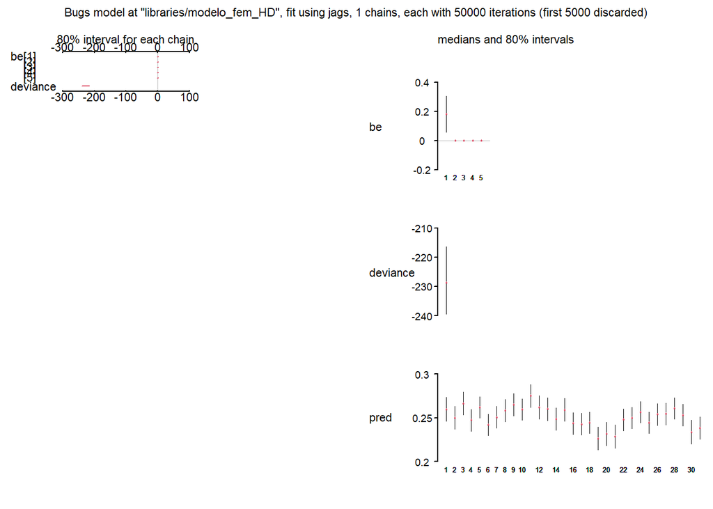

```r
#Ajuste del modelo
plot(jags_model_HD)
```

```r
jags_sims_HD <- jags_model_HD$BUGSoutput$sims.matrix %>% as.data.frame()

train_preds <- jags_sims_HD %>%
  dplyr::select(contains("pred")) %>%
  gather(parametro, sim) %>%
  mutate(mu_num = as.numeric(str_extract(parametro, '[0-9]+'))) %>%
  group_by(mu_num) %>%
  summarise(q_1 = quantile(sim, probs = 0.05),
            q_5 = median(sim),
            q_9 = quantile(sim, probs = 0.95),
            media = mean(sim)) %>%
  ungroup %>%
  cbind(share = train_HD$share_A) %>%
  dplyr::select(share, media, q_1:q_9)
# Coeficientes y significancia

coeficientes <- jags_sims_HD %>%
  dplyr::select(contains('be')) %>%
  gather(parametro, sim) %>%
  group_by(parametro) %>%
  summarise(q_1 = quantile(sim, probs = 0.1),
            mediana = median(sim),
            q_9 = quantile(sim, probs = 0.9),
            media = mean(sim),
            probs = 100*prob(sim),
            varianza = var(sim)) %>%
  ungroup %>%
  mutate(aux_param = str_extract(parametro, '(\\d)+'),
         aux_param_2 = str_extract(parametro, '^([[:alpha:]]*)')) %>%
  mutate(parametro = paste(aux_param_2, aux_param, sep = '_')) %>%
  dplyr::select(-aux_param_2, -aux_param) %>%
  left_join(coef_variables)
coeficientes %>% drop_na %>% print(n = 90)
```

```
## # A tibble: 5 x 8
##   parametro        q_1   mediana       q_9     media   probs varianza variable
##   <chr>          <dbl>     <dbl>     <dbl>     <dbl>   <dbl>    <dbl> <chr>
## 1 be_1         5.89e-2   1.81e-1   3.05e-1   1.81e-1 3.14e+0 9.79e- 3 Intercepto
## 2 be_2         5.98e-8   7.49e-8   9.01e-8   7.50e-8 0.      1.51e-16 ventas_un~
## 3 be_3        -8.67e-4   6.36e-4   2.15e-3   6.38e-4 2.91e+1 1.45e- 6 dist_num_B
## 4 be_4        -1.72e-3  -3.33e-4   1.07e-3  -3.32e-4 3.77e+1 2.52e- 6 agot_num_B
## 5 be_5        -3.24e-8  -2.60e-8  -1.96e-8  -2.60e-8 4.44e-3 2.64e-17 Ventas_un~
```

```r
# Métricas de ajuste

cor(train_preds$q_5, train_preds$share)^2
```

```
## [1] 0.9793429
```

```r
train_preds %>%
  mutate(err = abs((q_5-share)/share)) %>%
  dplyr::select(err) %>%
  as.matrix %>%
  median
```

```
## [1] 0.004082554
```

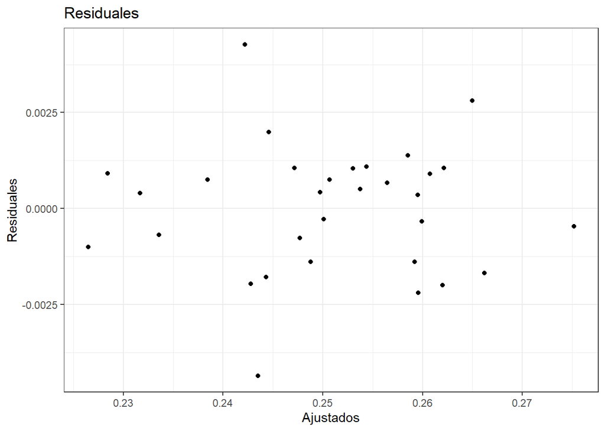

```r
# Análisis de residuales

train_res <- train_preds %>%
  mutate(res = share - media)

train_res %>%
  ggplot(aes(media, res)) +
  geom_point() +
  labs(title = 'Residuales', x = 'Ajustados', y = 'Residuales') +
  theme_bw()
```

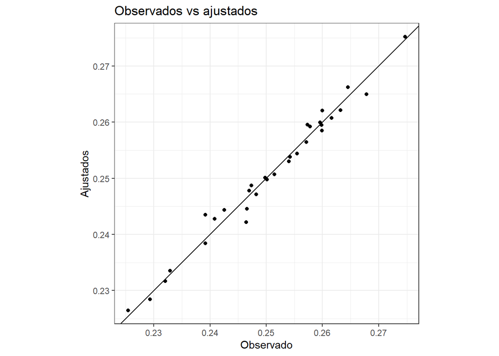

```r
# Gráfico de ajustados vs observados

train_preds %>%
  ggplot(aes(share, q_5)) +
  geom_point() +
  geom_abline(intercept = 0, slope = 1) +
  coord_equal() +
  labs(title = 'Observados vs ajustados', x = 'Observado', y = 'Ajustados') +
  theme(legend.position = 'bottom') +
  theme_bw()
```

```r
#Prediccióm

train_HD2 <- train_HD %>%
  rbind(test_HD %>%
          mutate(share_A = NA))

jags_HD2 <- list(
  share_A = train_HD2$share_A,
  ventas_unidades_A = train_HD2$ventas_unidades_A,
  dist_num_B = train_HD2$dist_num_B,
  agot_num_B = train_HD2$agot_num_B,
  ventas_unidades_B = train_HD2$ventas_unidades_B,
  n = nrow(train_HD),
  m = nrow(test_HD)
)

#Parametros a guardar

jags_param_HD2 <- c("be", "pred")

#JAGS
set.seed(1789152)
jags_model_HD2 <- jags(jags_HD2, jags.inits_HD, jags_param_HD2,
                   model.file = "libraries/modelo_fem_pronostico_HD",
                   n.iter = 50000,
                   n.chains = 1,
                   n.thin = 1,
                   n.burnin = 5000)
jags_sims_HD2 <- jags_model_HD2$BUGSoutput$sims.matrix %>% as.data.frame()

train_preds_HD <- jags_sims_HD2 %>%
  dplyr::select(contains("pred")) %>%
  gather(parametro, sim) %>%
  mutate(mu_num = as.numeric(str_extract(parametro, '[0-9]+'))) %>%
  group_by(mu_num) %>%
  summarise(q_1 = quantile(sim, probs = 0.05),
            q_5 = median(sim),
            q_9 = quantile(sim, probs = 0.95),
            media = mean(sim)) %>%
  ungroup %>%
  cbind(share_A = train_HD2$share_A) %>%
  dplyr::select(share_A, media, q_1:q_9)
```

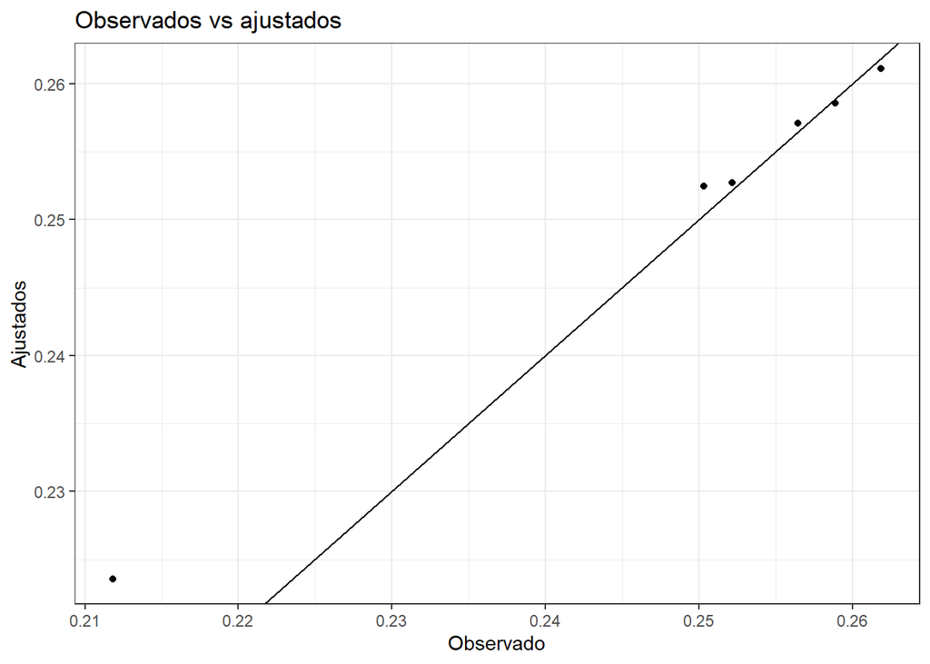

```r
ajuste_pronos_HD <- train_preds_HD %>%
  filter(is.na(share_A)) %>%
  dplyr::select(-share_A) %>%
  cbind(test_HD %>% dplyr::select(share_A)) %>%
  dplyr::select(share_A, q_5)

cor_HD <- cor(ajuste_pronos_HD$share_A, ajuste_pronos_HD$q_5)^2


ajuste_pronos_HD %>%
  ggplot(aes(share_A, q_5)) +
  geom_point() +
  geom_abline(intercept = 0, slope = 1) +
  labs(title = 'Observados vs ajustados', x = 'Observado', y = 'Ajustados') +
  theme(legend.position = 'bottom') +
  theme_bw()
```

### Guatemala

```r
#Datos train para El Salvador
train_GT <- datos_ajuste %>% filter(pais == "GT")
test_GT <- datos_prueba %>% filter(pais == "GT")

#Stepwise para ver cuales variables son las buenas
full_GT <- lm(share_A~., data = train_GT[,3:15])
step.model_GT <- stepAIC(full_GT, direction = "both", trace = FALSE)
summary(step.model_GT)
```

```
##
## Call:
## lm(formula = share_A ~ dist_num_A + agot_num_A + ventas_unidades_A +
##     inversion_promos_A + inversion_promos_tv_A + dist_num_B +
##     ventas_unidades_B + ppu_B + inventarios_B, data = train_GT[,
##     3:15])
##
## Residuals:
##        Min         1Q     Median         3Q        Max
## -0.0064111 -0.0011978 -0.0001201  0.0017258  0.0046272
##
## Coefficients:
##                         Estimate Std. Error t value Pr(>|t|)
## (Intercept)            3.444e-01  5.751e-02   5.988 6.08e-06 ***
## dist_num_A             1.311e-03  4.179e-04   3.137  0.00497 **
## agot_num_A            -9.320e-04  5.368e-04  -1.736  0.09716 .
## ventas_unidades_A      6.017e-08  4.993e-09  12.052 6.72e-11 ***
## inversion_promos_A    -8.995e-07  6.685e-07  -1.346  0.19279
## inversion_promos_tv_A  9.305e-07  6.881e-07   1.352  0.19069
## dist_num_B            -8.859e-04  5.426e-04  -1.633  0.11746
## ventas_unidades_B     -2.512e-08  2.021e-09 -12.428 3.80e-11 ***
## ppu_B                 -4.053e-02  1.481e-02  -2.736  0.01238 *
## inventarios_B          1.622e-09  1.324e-09   1.225  0.23411
## ---
## Signif. codes:  0 '***' 0.001 '**' 0.01 '*' 0.05 '.' 0.1 ' ' 1
##
## Residual standard error: 0.00325 on 21 degrees of freedom
## Multiple R-squared:  0.978,  Adjusted R-squared:  0.9686
## F-statistic: 103.8 on 9 and 21 DF,  p-value: 2.304e-15
```

```r
#Almacenamiento de variables
jags_GT <- list(
  share_A = train_GT$share_A,
  dist_num_A = train_GT$dist_num_A,
  agot_num_A = train_GT$dist_num_A,
  ventas_unidades_A = train_GT$ventas_unidades_A,
  dist_num_B = train_GT$dist_num_B,
  ventas_unidades_B = train_GT$ventas_unidades_B,
  ppu_B = train_GT$ppu_B,
  inventarios_B = train_GT$inventarios_B,
  n = nrow(train_GT)
)

#Declaración distribuciones iniciales (no informativas)
jags.inits_GT <- function(){
  list(be = rep(0,8),
       tau = 1)
}

# Seleccionamos los parámetros a monitorear
jags_param_GT <- c("be", "pred")

# Asociamos variables con coeficientes

coef_variables <- data.frame(
  parametro = c(paste0('be_', 1:8)),
  variable = c('Intercepto',
               'dist_num_A',
               'agot_num_A',
               'ventas_unidades_A',
               'dist_num_B',
               'Ventas_unidades_B',
               'ppu_B',
               'inventarios_B')
)


# Codigo
set.seed(17891525)
jags_model_GT <- jags(jags_GT, jags.inits_GT, jags_param_GT,
                   model.file = "libraries/modelo_fem_GT",
                   n.iter = 50000,
                   n.chains = 1,
                   n.thin = 1,
                   n.burnin = 5000)
```

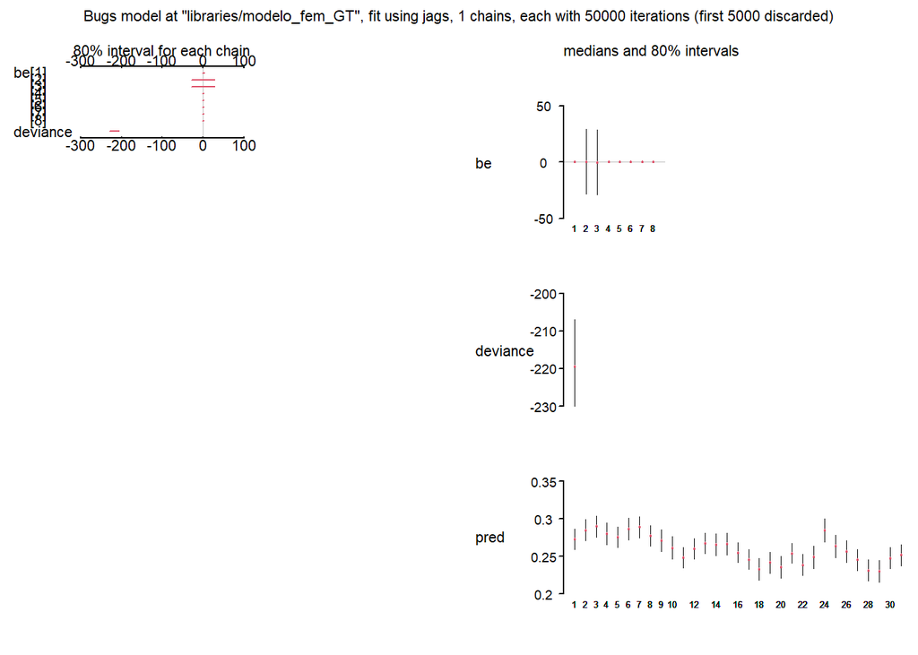

```r
#Ajuste del modelo
plot(jags_model_GT)
```

```r
jags_sims_GT <- jags_model_GT$BUGSoutput$sims.matrix %>% as.data.frame()

train_preds <- jags_sims_GT %>%
  dplyr::select(contains("pred")) %>%
  gather(parametro, sim) %>%
  mutate(mu_num = as.numeric(str_extract(parametro, '[0-9]+'))) %>%
  group_by(mu_num) %>%
  summarise(q_1 = quantile(sim, probs = 0.05),
            q_5 = median(sim),
            q_9 = quantile(sim, probs = 0.95),
            media = mean(sim)) %>%
  ungroup %>%
  cbind(share = train_GT$share_A) %>%
  dplyr::select(share, media, q_1:q_9)
# Coeficientes y significancia

coeficientes <- jags_sims_GT %>%
  dplyr::select(contains('be')) %>%
  gather(parametro, sim) %>%
  group_by(parametro) %>%
  summarise(q_1 = quantile(sim, probs = 0.1),
            mediana = median(sim),
            q_9 = quantile(sim, probs = 0.9),
            media = mean(sim),
            probs = 100*prob(sim),
            varianza = var(sim)) %>%
  ungroup %>%
  mutate(aux_param = str_extract(parametro, '(\\d)+'),
         aux_param_2 = str_extract(parametro, '^([[:alpha:]]*)')) %>%
  mutate(parametro = paste(aux_param_2, aux_param, sep = '_')) %>%
  dplyr::select(-aux_param_2, -aux_param) %>%
  left_join(coef_variables)
coeficientes %>% drop_na %>% print(n = 90)
```

```
## # A tibble: 8 x 8
##   parametro      q_1  mediana      q_9    media   probs varianza variable
##   <chr>        <dbl>    <dbl>    <dbl>    <dbl>   <dbl>    <dbl> <chr>
## 1 be_1       1.40e-1  3.47e-1  5.58e-1  3.47e-1  1.86   2.74e- 2 Intercepto
## 2 be_2      -2.85e+1  4.15e-1  2.90e+1  2.95e-1 49.3    5.05e+ 2 dist_num_A
## 3 be_3      -2.90e+1 -4.15e-1  2.85e+1 -2.94e-1 49.3    5.05e+ 2 agot_num_A
## 4 be_4       3.82e-8  5.69e-8  7.53e-8  5.69e-8  0.0311 2.20e-16 ventas_unidade~
## 5 be_5      -2.90e-3 -8.57e-4  1.18e-3 -8.59e-4 29.2    2.79e- 6 dist_num_B
## 6 be_6      -3.26e-8 -2.46e-8 -1.68e-8 -2.47e-8  0.0267 4.00e-17 Ventas_unidade~
## 7 be_7      -9.59e-2 -4.04e-2  1.46e-2 -4.04e-2 17.1    1.97e- 3 ppu_B
## 8 be_8      -3.53e-9  1.56e-9  6.64e-9  1.57e-9 34.6    2.23e-17 inventarios_B
```

```r
# Métricas de ajuste

cor(train_preds$q_5, train_preds$share)^2
```

```
## [1] 0.9718184
```

```r
train_preds %>%
  mutate(err = abs((q_5-share)/share)) %>%
  dplyr::select(err) %>%
  as.matrix %>%
  median
```

```
## [1] 0.007645059
```

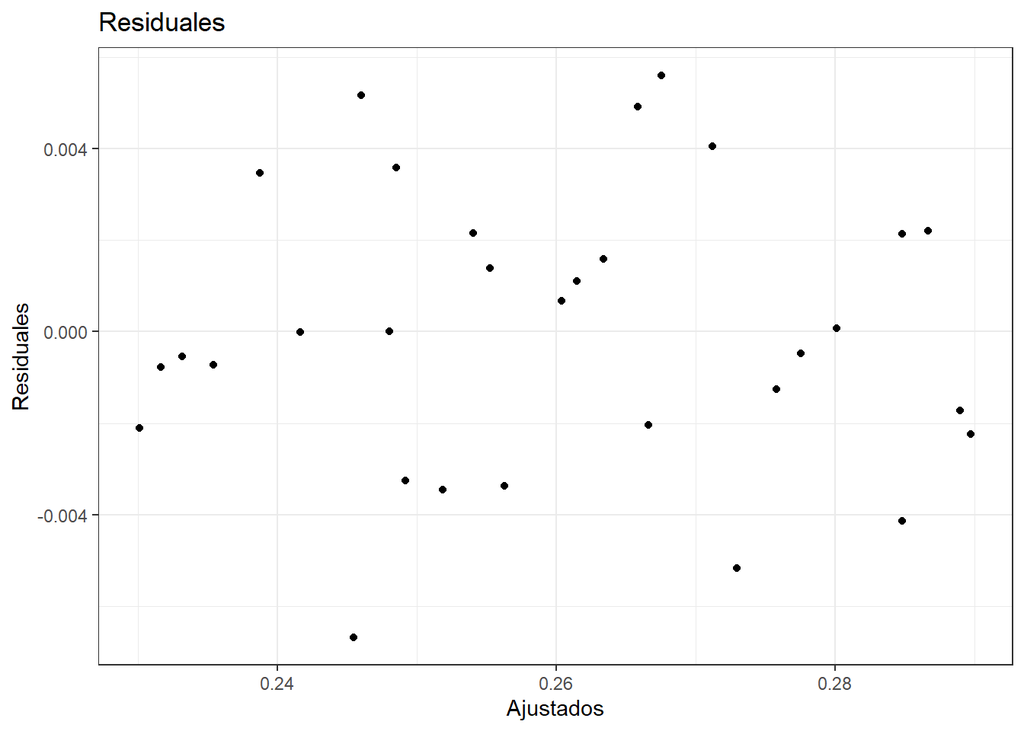

```r
# Análisis de residuales

train_res <- train_preds %>%
  mutate(res = share - media)

train_res %>%
  ggplot(aes(media, res)) +
  geom_point() +
  labs(title = 'Residuales', x = 'Ajustados', y = 'Residuales') +
  theme_bw()
```

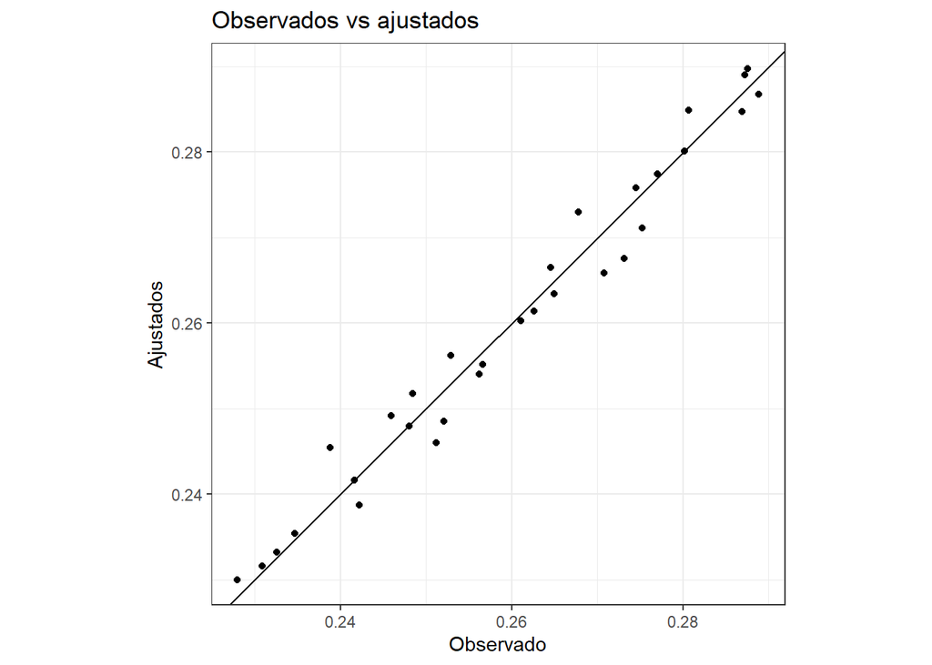

```r
# Gráfico de ajustados vs observados

train_preds %>%
  ggplot(aes(share, q_5)) +
  geom_point() +
  geom_abline(intercept = 0, slope = 1) +
  coord_equal() +
  labs(title = 'Observados vs ajustados', x = 'Observado', y = 'Ajustados') +
  theme(legend.position = 'bottom') +
  theme_bw()
```

```r
#Prediccióm

train_GT2 <- train_GT %>%
  rbind(test_GT %>%
          mutate(share_A = NA))

jags_GT2 <- list(
  share_A = train_GT2$share_A,
  dist_num_A = train_GT2$dist_num_A,
  agot_num_A = train_GT2$agot_num_A,
  ventas_unidades_A = train_GT2$ventas_unidades_A,
  dist_num_B = train_GT2$dist_num_B,
  ventas_unidades_B = train_GT2$ventas_unidades_B,
  ppu_B = train_GT2$ppu_B,
  inventarios_B = train_GT2$inventarios_B,
  n = nrow(train_GT),
  m = nrow(test_GT)
)

#Parametros a guardar

jags_param_GT2 <- c("be", "pred")

#JAGS
set.seed(1789152)
jags_model_GT2 <- jags(jags_GT2, jags.inits_GT, jags_param_GT2,
                   model.file = "libraries/modelo_fem_pronostico_GT",
                   n.iter = 50000,
                   n.chains = 1,
                   n.thin = 1,
                   n.burnin = 5000)
jags_sims_GT2 <- jags_model_GT2$BUGSoutput$sims.matrix %>% as.data.frame()

train_preds_GT <- jags_sims_GT2 %>%
  dplyr::select(contains("pred")) %>%
  gather(parametro, sim) %>%
  mutate(mu_num = as.numeric(str_extract(parametro, '[0-9]+'))) %>%
  group_by(mu_num) %>%
  summarise(q_1 = quantile(sim, probs = 0.05),
            q_5 = median(sim),
            q_9 = quantile(sim, probs = 0.95),
            media = mean(sim)) %>%
  ungroup %>%
  cbind(share_A = train_GT2$share_A) %>%
  dplyr::select(share_A, media, q_1:q_9)
```

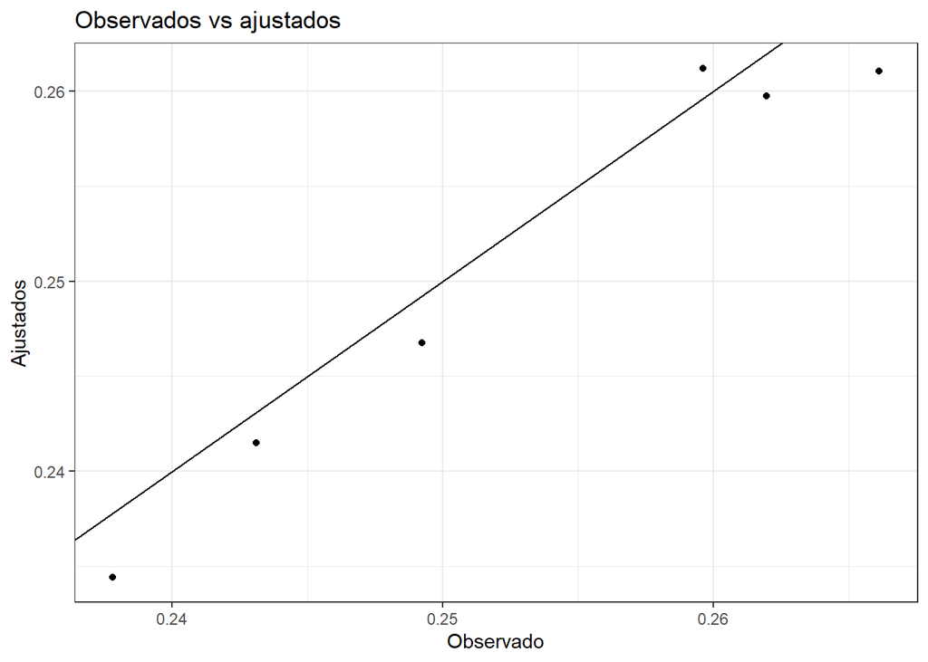

```r
ajuste_pronos_GT <- train_preds_GT %>%
  filter(is.na(share_A)) %>%
  dplyr::select(-share_A) %>%
  cbind(test_GT %>% dplyr::select(share_A)) %>%
  dplyr::select(share_A, q_5)

cor_GT <- cor(ajuste_pronos_GT$share_A, ajuste_pronos_GT$q_5)^2


ajuste_pronos_GT %>%
  ggplot(aes(share_A, q_5)) +
  geom_point() +
  geom_abline(intercept = 0, slope = 1) +
  labs(title = 'Observados vs ajustados', x = 'Observado', y = 'Ajustados') +
  theme(legend.position = 'bottom') +
  theme_bw()
```

### Costa Rica

```r
#Datos train para El Salvador
train_CR <- datos_ajuste %>% filter(pais == "CR")
test_CR <- datos_prueba %>% filter(pais == "CR")

#En este caso utilizamos como regesores a las variables de mayor correlación

#Almacenamiento de variables
jags_CR <- list(
  share_A = train_CR$share_A,
  ventas_unidades_A = train_CR$ventas_unidades_A,
  ppu_A = train_CR$ppu_A,
  inventarios_A = train_CR$inventarios_A,
  n = nrow(train_CR)
)

#Declaración distribuciones iniciales (no informativas)
jags.inits_CR <- function(){
  list(be = rep(0,4),
       tau = 1)
}

# Seleccionamos los parámetros a monitorear
jags_param_CR <- c("be", "pred")

# Asociamos variables con coeficientes

coef_variables <- data.frame(
  parametro = c(paste0('be_', 1:4)),
  variable = c('Intercepto',
               'ventas_unidades_A',
               'ppu_A',
               'inventarios_A')
)


# Codigo
set.seed(17891525)
jags_model_CR <- jags(jags_CR, jags.inits_CR, jags_param_CR,
                   model.file = "libraries/modelo_fem_CR",
                   n.iter = 50000,
                   n.chains = 1,
                   n.thin = 1,
                   n.burnin = 5000)
```

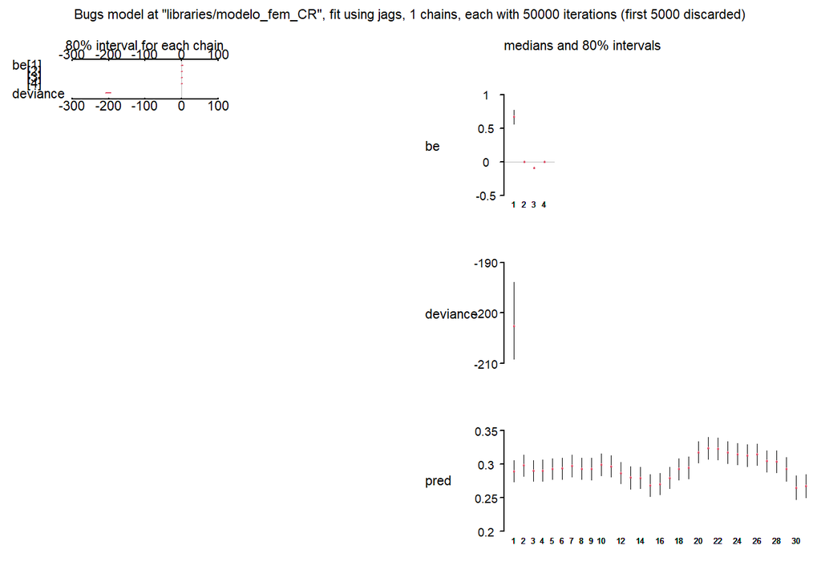

```r
#Ajuste del modelo
plot(jags_model_CR)
```

```r
jags_sims_CR <- jags_model_CR$BUGSoutput$sims.matrix %>% as.data.frame()

train_preds <- jags_sims_CR %>%
  dplyr::select(contains("pred")) %>%
  gather(parametro, sim) %>%
  mutate(mu_num = as.numeric(str_extract(parametro, '[0-9]+'))) %>%
  group_by(mu_num) %>%
  summarise(q_1 = quantile(sim, probs = 0.05),
            q_5 = median(sim),
            q_9 = quantile(sim, probs = 0.95),
            media = mean(sim)) %>%
  ungroup %>%
  cbind(share = train_CR$share_A) %>%
  dplyr::select(share, media, q_1:q_9)
# Coeficientes y significancia

coeficientes <- jags_sims_CR %>%
  dplyr::select(contains('be')) %>%
  gather(parametro, sim) %>%
  group_by(parametro) %>%
  summarise(q_1 = quantile(sim, probs = 0.1),
            mediana = median(sim),
            q_9 = quantile(sim, probs = 0.9),
            media = mean(sim),
            probs = 100*prob(sim),
            varianza = var(sim)) %>%
  ungroup %>%
  mutate(aux_param = str_extract(parametro, '(\\d)+'),
         aux_param_2 = str_extract(parametro, '^([[:alpha:]]*)')) %>%
  mutate(parametro = paste(aux_param_2, aux_param, sep = '_')) %>%
  dplyr::select(-aux_param_2, -aux_param) %>%
  left_join(coef_variables)
coeficientes %>% drop_na %>% print(n = 90)
```

```
## # A tibble: 4 x 8
##   parametro        q_1  mediana        q_9    media   probs varianza variable
##   <chr>          <dbl>    <dbl>      <dbl>    <dbl>   <dbl>    <dbl> <chr>
## 1 be_1         5.62e-1  6.65e-1    7.69e-1  6.65e-1 2.22e-3 7.06e- 3 Intercepto
## 2 be_2         1.23e-8  3.87e-8    6.56e-8  3.88e-8 3.37e+0 4.61e-16 ventas_uni~
## 3 be_3        -1.07e-1 -8.99e-2   -7.33e-2 -8.99e-2 2.22e-3 2.26e- 4 ppu_A
## 4 be_4        -3.92e-8  1.63e-9    4.25e-8  1.67e-9 4.79e+1 1.20e-15 inventario~
```

```r
# Métricas de ajuste

cor(train_preds$q_5, train_preds$share)^2
```

```
## [1] 0.8257637
```

```r
train_preds %>%
  mutate(err = abs((q_5-share)/share)) %>%
  dplyr::select(err) %>%
  as.matrix %>%
  median
```

```
## [1] 0.01737809
```

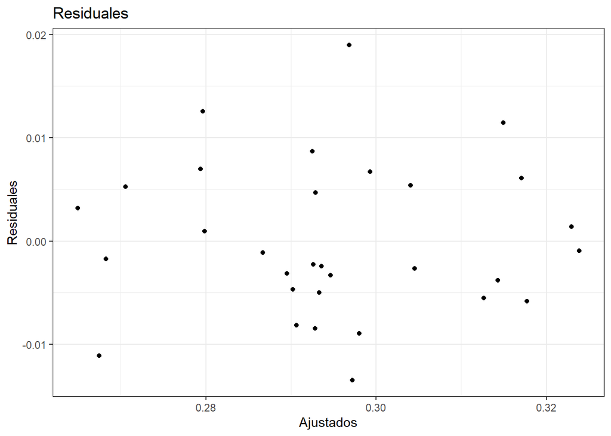

```r
# Análisis de residuales

train_res <- train_preds %>%
  mutate(res = share - media)

train_res %>%
  ggplot(aes(media, res)) +
  geom_point() +
  labs(title = 'Residuales', x = 'Ajustados', y = 'Residuales') +
  theme_bw()
```

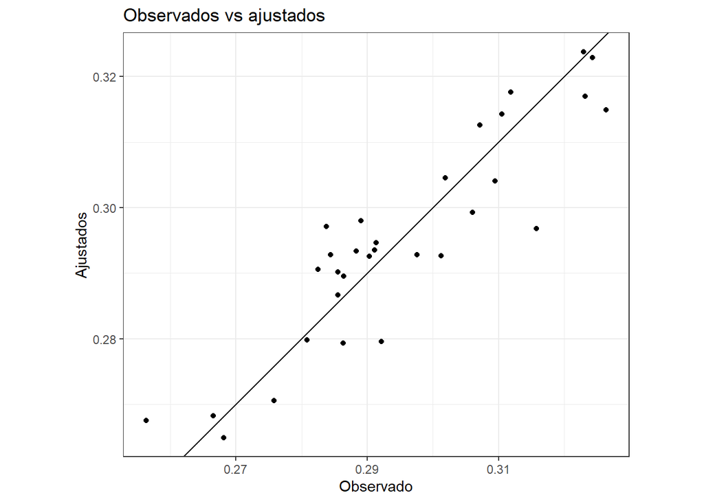

```r
# Gráfico de ajustados vs observados

train_preds %>%
  ggplot(aes(share, q_5)) +
  geom_point() +
  geom_abline(intercept = 0, slope = 1) +
  coord_equal() +
  labs(title = 'Observados vs ajustados', x = 'Observado', y = 'Ajustados') +
  theme(legend.position = 'bottom') +
  theme_bw()
```

```r
#Prediccióm

train_CR2 <- train_CR %>%
  rbind(test_CR %>%
          mutate(share_A = NA))

jags_CR2 <- list(
  share_A = train_CR2$share_A,
  ventas_unidades_A = train_CR2$ventas_unidades_A,
  ppu_A = train_CR2$ppu_A,
  inventarios_A = train_CR2$inventarios_A,
  n = nrow(train_CR),
  m = nrow(test_CR)
)

#Parametros a guardar

jags_param_CR2 <- c("be", "pred")

#JAGS
set.seed(1789152)
jags_model_CR2 <- jags(jags_CR2, jags.inits_CR, jags_param_CR2,
                   model.file = "libraries/modelo_fem_pronostico_CR",
                   n.iter = 50000,
                   n.chains = 1,
                   n.thin = 1,
                   n.burnin = 5000)
jags_sims_CR2 <- jags_model_CR2$BUGSoutput$sims.matrix %>% as.data.frame()

train_preds_CR <- jags_sims_CR2 %>%
  dplyr::select(contains("pred")) %>%
  gather(parametro, sim) %>%
  mutate(mu_num = as.numeric(str_extract(parametro, '[0-9]+'))) %>%
  group_by(mu_num) %>%
  summarise(q_1 = quantile(sim, probs = 0.05),
            q_5 = median(sim),
            q_9 = quantile(sim, probs = 0.95),
            media = mean(sim)) %>%
  ungroup %>%
  cbind(share_A = train_CR2$share_A) %>%
  dplyr::select(share_A, media, q_1:q_9)
```

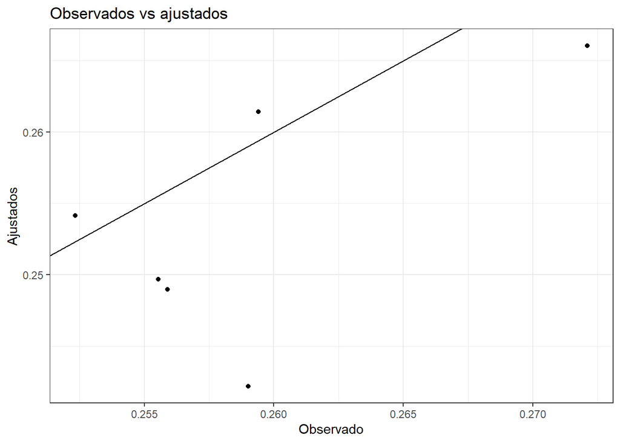

```r
ajuste_pronos_CR <- train_preds_CR %>%
  filter(is.na(share_A)) %>%
  dplyr::select(-share_A) %>%
  cbind(test_CR %>% dplyr::select(share_A)) %>%
  dplyr::select(share_A, q_5)

cor_CR <- cor(ajuste_pronos_CR$share_A, ajuste_pronos_CR$q_5)^2


ajuste_pronos_CR %>%
  ggplot(aes(share_A, q_5)) +
  geom_point() +
  geom_abline(intercept = 0, slope = 1) +
  labs(title = 'Observados vs ajustados', x = 'Observado', y = 'Ajustados') +
  theme(legend.position = 'bottom') +
  theme_bw()
```

## Modelo Final

```r
ajuste_pronos_GT <- ajuste_pronos_GT %>% mutate(Pais = "Guatemala")
ajuste_pronos_CR <- ajuste_pronos_CR %>% mutate(Pais = "Costa Rica")
ajuste_pronos_EL <- ajuste_pronos_EL %>% mutate(Pais = "El Salvador")
ajuste_pronos_HD <- ajuste_pronos_HD %>% mutate(Pais = "Honduras")
ajuste_pronos_NIC <- ajuste_pronos_NIC %>% mutate(Pais = "Nicaragua")
ajuste_pronos_PTY <- ajuste_pronos_PTY %>% mutate(Pais = "Panama")

Resultados_pred <- rbind(ajuste_pronos_GT, ajuste_pronos_HD, ajuste_pronos_CR, ajuste_pronos_PTY, ajuste_pronos_NIC, ajuste_pronos_EL) %>% as.data.frame()
names(Resultados_pred) <- c("Observado", "Ajustado", "Pais")
Resultados_pred <- Resultados_pred[,c(3,1,2)]

#Creamos columna de Diferencia entre Observado y ajustado
Resultados_pred <- Resultados_pred %>% mutate(Error = Resultados_pred$Observado - Resultados_pred$Ajustado)
print(Resultados_pred)
```

```
##           Pais Observado  Ajustado         Error
## 1    Guatemala 0.2619716 0.2597377  0.0022339205
## 2    Guatemala 0.2377979 0.2344317  0.0033661566
## 3    Guatemala 0.2596072 0.2612119 -0.0016047448
## 4    Guatemala 0.2661375 0.2610482  0.0050892923
## 5    Guatemala 0.2492342 0.2467539  0.0024802232
## 6    Guatemala 0.2430962 0.2415093  0.0015869062
## 7     Honduras 0.2618725 0.2611342  0.0007382360
## 8     Honduras 0.2521657 0.2527133 -0.0005476213
## 9     Honduras 0.2564389 0.2570759 -0.0006369437
## 10    Honduras 0.2588811 0.2585524  0.0003287447
## 11    Honduras 0.2503053 0.2524747 -0.0021694537
## 12    Honduras 0.2118240 0.2235746 -0.0117505748
## 13  Costa Rica 0.2721076 0.2660418  0.0060658529
## 14  Costa Rica 0.2558973 0.2489657  0.0069316539
```

[output cut: 22 more lines]

```r
#Observamos valores minimos, maximos y media para la diferencia en cada pais
Resultados_pred <- Resultados_pred %>% group_by(Pais) %>% summarise(Diferencia_Minima = min(Error), Diferencia_Maxima = max(Error), Diferencia_Media = mean(Error), SD = sd(Error))
#ordenamos el DF de mayor a menor en diferencia media
Resultados_pred <- Resultados_pred[order(abs(Resultados_pred$Diferencia_Media)),]
Resultados_pred
```

```
## # A tibble: 6 x 5
##   Pais        Diferencia_Minima Diferencia_Maxima Diferencia_Media      SD
##   <chr>                   <dbl>             <dbl>            <dbl>   <dbl>
## 1 Nicaragua            -0.00263          0.0143            0.00112 0.00652
## 2 Guatemala            -0.00160          0.00509           0.00219 0.00222
## 3 Honduras             -0.0118           0.000738         -0.00234 0.00472
## 4 Costa Rica           -0.00201          0.0168            0.00531 0.00692
## 5 El Salvador          -0.0124           0.0507            0.00702 0.0223
## 6 Panama                0.0118           0.0520            0.0239  0.0145
```

Recordemos que las variables explicativas en los modelos por pais fueron:

Observamos que aquellos modelos que tomaron como variables explicativas únicamente a una o ninguna variable para un fabricante y las demás variables explicativas para el otro fabricante, fueron los que mayor error tuvieron al momento de ajustar.

Mientras que aquellos modelos que incorporaron un número más equilibrado entre variables de ambos fabricantes, tuvieron un mejor ajuste.

## Conclusión

Podemos observar que aquellos paises cuyo modelo arroja como resultados que las variables explicativas son únicamente sus ventas y la información relativa a la competencia, presentan un crecimiento a través del tiempo en su poder de mercado. Esto puede deberse a que dichos paises se encuentran en una situación de oligopolio, pues no poseen un participación de mercado lo suficientemente grande para considerarse como monopolio, y no hay una eficiencia en el mercado local.

La hipótesis se confirma con dos fuentes:

1. El gráfico presentado en la sección de series de tiempo nos muestra que justamente esos paises son los que presentan un alto nivel de participación incial de mercado que simplemente va creciendo con el tiempo debido a la crecimiento de la economía.
2. El modelo para Nicaragua arroja resultados en los que podemos ver que su participación se ve influenciada por las ventas, el precio por unidad y los inventarios tanto propios, como de la competencia. Es decir, podemos observar una competencia en precios que confirma la presencia de un oligopolio.

Por lo tanto, buscar M&A con empresas que tengan un gran número de puntos de distribución, que como leimos en el artículo de Rhoades, es de vital importancia para el aumento de la participación de mercado. Los gastos destinados a publicidad pueden ser ahorrados al crear sinergias con otras empresas que cumplan con esta característica particular.